# Exploring Loan Data

# Multivariate Analysis

From the plots in the multivariate plots secion I was able to observe that there exists a positive correlation between the borrower’s income range and their stated monthly income (to be expected), and that as the income range / stated monthly income increases the upper limit for the original loan amount (and hence the monthly loan payment) and the variance of the original loan amount increase.

I also observed that the larger the income range, the more likely the borrower to be a homeowner and that homeowners seem to have slightly larger amount of revolving credit balances than non-homeowners.

# Final Plots and Summary

### Plot 1

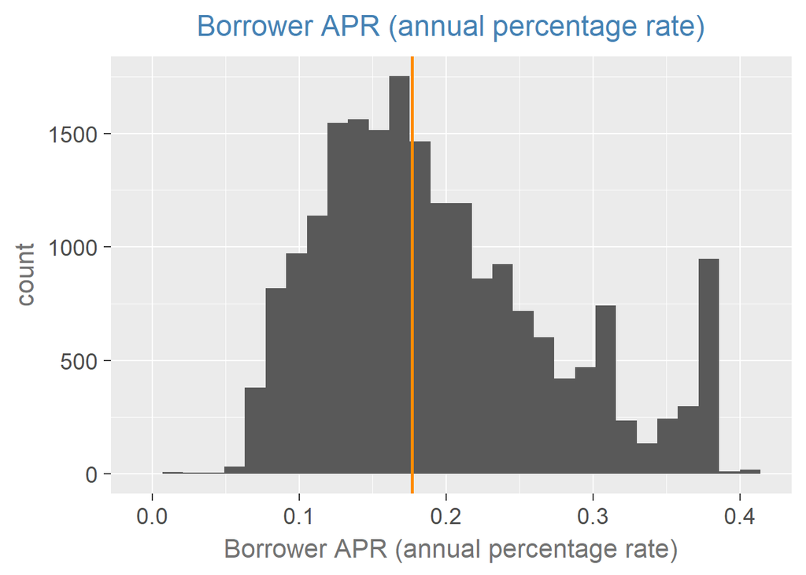

### Plot 1 - Description

What I learned in this plot was my first surprising discovery from the data set. Here, I was able to observe that the median borrowers’ APR is $\$17.72$ and the APR could go as high as $\$41.36.$ This shows that loans are very costly propositions.

### Plot 2

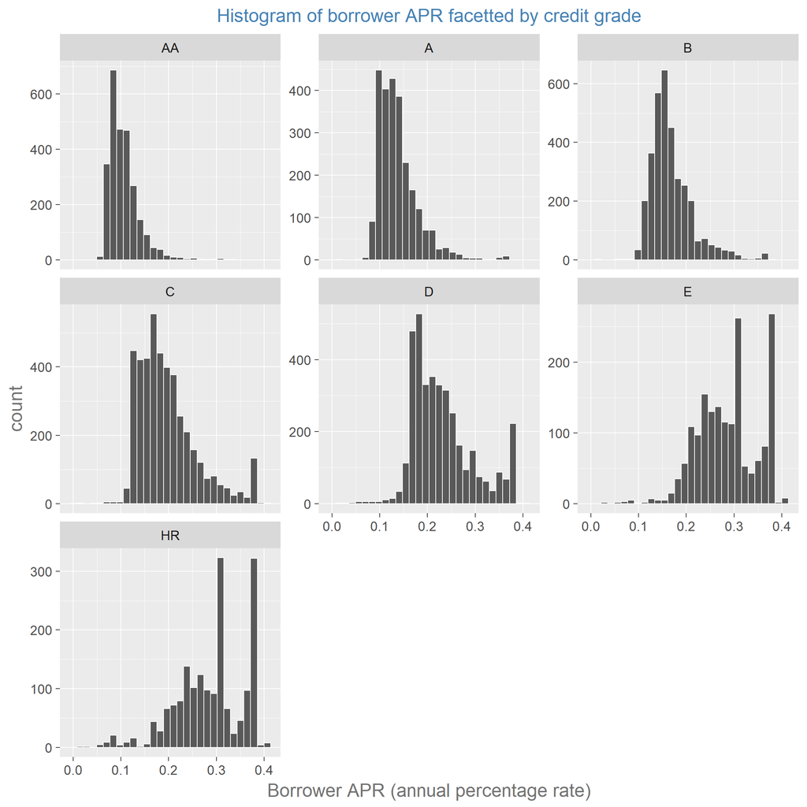

### Plot 2 - Description

I chose this plot as one of my summary plots because it has answered one of my questions at the beginning of this project - do borrowers with better credit grades generally get loans with lower APRs? This plots answers this question in the affirmative. Recall that credit grades have the numerical values:
$$(\text{NC}\leftrightarrow 0) < (\text{HR}\leftrightarrow 1)< (\text{E}\leftrightarrow 2)< (\text{D}\leftrightarrow 3)< (\text{C}\leftrightarrow 4)< (\text{B} \leftrightarrow 5)< (\text{A}\leftrightarrow 6)< (\text{AA}\leftrightarrow 7)$$

### Plot 3

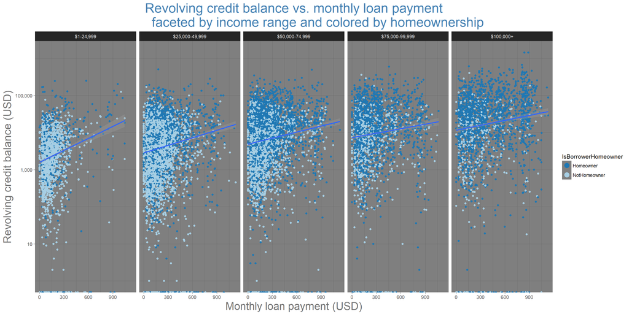

### Plot 3 - Description

This plot shows the relationships between four different variables - revolving credit balance, monthly loan payment, income range, and homeownership. For this reason, it tells a lot of stories.

First it is a scatter plot of revolving credit balance (in log10 scale) vs. monthly loan payment, faceted by income range and colored by homeownership. We can learn several things from this plot. Some of the things we can observe in the plot are:

- the larger the income the more likely the borrower to be a homeowner
- homeowners in general have slighly more revolving credit balances than non-homeowners
- there exists a positive correlation between revolving credit balance and monthly loan payment
- we can also see that as income range increases the average amount of revolving credit balance increases.

# Reflection

The [Loan Data set from Prosper](https://www.google.com/url?q=https://s3.amazonaws.com/udacity-hosted-downloads/ud651/prosperLoanData.csv&sa=D&ust=1531485914213000) for this project contains 113,937 loans with 81 variables. The large number of variables in the data set appeared to be intimidating at first. Figuring out which variables might be related to one another seemed a daunting task as there were so many variables to choose from. Moreover, the first few variables that I plotted did not seem to have any interesting features and I was sure I was going to change the data set I was going to work with. But then I thought about the questions I would like to answer using this data set and that made the selection of the variables to look into a lot easier and as I plotted some more of these variables, interesting features and relationships started to emerge. These positive developments and observations also encouraged me to continue to work with the data set.

With the plots I was able to generate from the variables I considered from the data set, I was able to answer my initial questions. Some of the answers I got to questions as to - whether better credit scores lead to loans with lower APRs (annual percentage rates) for borrowers - were in the affirmative confirming my initial intuitions; better credit scores indeed result in borrowers getting loans with lower APRs and also the better the borrower’s credit score the larger original loan amount the borrower could get (if the borrower chose to). The another question I asked - whether higher income implied little or no delinquency on loan - the answer looked counter-intuitive to me at first; the higer the income range the larger the median delinquent amount got. After more careful thought this answer made sense (as the larger the borrower’s income the less likely the borrower becomes delinquent on a small amount under normal circumstances). Then I refined my question and asked - whether higher income implied less chance of the borrower becoming delinquent on any loan amount. To answer this question, I created a new variable for the probability of becoming delinquent on loan calculated by income range, and the answer turned out to be in the affirmative - the higher the income the lesser the probability of delinquency (with and exception at the lowest income bracket, $1-24,999).

There were a lot of observations that I removed from the data set due to missing information - for example a substantial number of observations (loans) did not have credit grades associated for them or for which employment status was not available. However, since the data set is a very large data set (with about 114,000 observations), I though this limitation was not going to be a big issue (but it’s something one should be mindful of).

Finally, due to the enormity of the number of variables in the data set, I only got to scratch the surface with the data set and there are possibly many more relationships among the variables yet to be discovered with the data set, and I plan on researching the data set for possibly other interesting relationships.